# Incidence of Severe Weather Events Over Public Health and economic on EEUU

Gregorio Corral

22 de abril de 2017

# Incidence of Severe Weather Events Over Public Health and economic on EEUU

Storms and other severe weather events can cause both public health and economic problems for communities and municipalities. Many severe events can result in fatalities, injuries, and property damage, and preventing such outcomes to the extent possible is a key concern.

This project involves exploring the U.S. National Oceanic and Atmospheric Administration’s (NOAA) storm database. This database tracks characteristics of major storms and weather events in the United States, including when and where they occur, as well as estimates of any fatalities, injuries, and property damage.

## Synopsis

The objetive of this analisys is to explore the NOAA Storm Database and answer some basic questions about severe weather events. The questions are:

1. Across the United States, which types of events (as indicated in the 𝙴𝚅𝚃𝚈𝙿𝙴 variable) are most harmful with respect to population health?
2. Across the United States, which types of events have the greatest economic consequences?

## Data Processing

Source data is [Storme Data](https://d396qusza40orc.cloudfront.net/repdata%2Fdata%2FStormData.csv.bz2). The data come in the form of a comma-separated-value file compressed via the bzip2 algorithm.

Donwload bzip2 file and load data:

```r
if ( ! file.exists("StormData.csv.bz2") ) {
    print("Downloading the file from source:")
    download.file("https://d396qusza40orc.cloudfront.net/repdata%2Fdata%2FStormData.csv.bz2",
                  destfile = "StormData.csv.bz2")
}


if( ! "StormData" %in% ls() ) {
  StormData = read.csv("StormData.csv.bz2")
}
```

Filter colums:

- EVTYPE (Storm Data Event)
- BGN_DATE (Beginning time for each event )
- FATALITIES (Fatalities caused by the event)
- INJURIES (Injuries cused by the event)
- PROPDMG (Property damage estimates in dollars)

```r
NormStormData <- StormData[,c("EVTYPE","BGN_DATE","FATALITIES","INJURIES","PROPDMG")]
```

Convert dates to POSIXct format and add year colum:

```r
NormStormData$BGN_DATE <- as.POSIXct(NormStormData$BGN_DATE, format="%e/%M/%Y %H:%M:%S")
NormStormData$YEAR = year(NormStormData$BGN_DATE)
```

Remove summary entries:

```r
NormStormData <- NormStormData[-grep("^.*(SUMMARY|Summary).*$",NormStormData$EVTYPE),]
```

Normalize storm data event (EVTYPE). There are a serie of different names for several events. For example, THUNDERSTORM WIND events could be found as; TSTM WIND/HAIL, STM WIND 45, MARINE THUNDERSTORM WIND, MARINE TSTM WIND …

```r
NormStormData$EVTYPE <- gsub("^.*(MICROBURST|TORNDA|TORNADO|WIND|LIG(H|N)T(N|)ING|T(H|)U(N|)(DER|ER|DEER|DERE)(STORM|STROM|TORM)|TSTM|HAIL).*$",
                             "WIND", NormStormData$EVTYPE, ignore.case = TRUE)

NormStormData$EVTYPE <- gsub("^.*(WINT(ER|RY)|ICE|AVALANC(H|)E|SNOW|BLIZZARD|FREEZ|ICY|FROST).*$",
                             "WINTER", NormStormData$EVTYPE, ignore.case = TRUE)

NormStormData$EVTYPE <- gsub("^.*(COLD|HEAT|HOT|TEMPERATURE|COOL|WARM).*$",
                             "TEMPERATURE", NormStormData$EVTYPE, ignore.case = TRUE)

NormStormData$EVTYPE <- gsub("^.*(FLOOD| FLD).*$",
                             "FLOOD", NormStormData$EVTYPE, ignore.case = TRUE)

NormStormData$EVTYPE <- gsub("^.*(TIDE|COASTAL|TSUNAMI|RIP CURRENT|MARINE|WATERSPOUT|SURF|SLEET|SEAS|(HIGH|RISING|HEAVY) (WAVES|SWELLS|WATER)).*$", "MARINE", NormStormData$EVTYPE, ignore.case = TRUE)

NormStormData$EVTYPE <- gsub("^.*(TROPICAL|HURRICANE|STORM SURGE|TYPHOON).*$",
                             "CYCLONES", NormStormData$EVTYPE, ignore.case = TRUE)

NormStormData$EVTYPE <- gsub("^.*(RAIN|PRECIP).*$",
                             "RAIN", NormStormData$EVTYPE, ignore.case = TRUE)

NormStormData$EVTYPE <- gsub("^.*FIRE.*$",
                             "FIRE", NormStormData$EVTYPE, ignore.case = TRUE)

NormStormData$EVTYPE <- gsub("^.*(DROUGHT|DUST).*$",
                             "DUST", NormStormData$EVTYPE, ignore.case = TRUE)

#NormStormData$EVTYPE <- gsub("^.*(LANDSLIDE|MUD.*SLIDE).*$",
#                             "LANDSLIDE", NormStormData$EVTYPE, ignore.case = TRUE)

NormStormData$EVTYPE <- gsub("^.*(FOG|VOG).*$",
                             "FOG", NormStormData$EVTYPE, ignore.case = TRUE)

#NormStormData$EVTYPE <- gsub("^.*(VOLCANIC).*$",
#                             "VOLCANIC", NormStormData$EVTYPE, ignore.case = TRUE)

#NormStormData$EVTYPE <- gsub("^.*(WET).*$",
#                             "WET", NormStormData$EVTYPE, ignore.case = TRUE)

#NormStormData$EVTYPE <- gsub("^.*(DRY).*$",
#                             "DRY", NormStormData$EVTYPE, ignore.case = TRUE)

#NormStormData$EVTYPE <- gsub("^.*(FUNNEL).*$",
#                             "FUNNEL CLOUD", NormStormData$EVTYPE, ignore.case = TRUE)


#evtype_set <- c("WIND","WINTER","TEMPERATURE","FLOOD","MARINE","CYCLONES","RAIN","FIRE","DUST","LANDSLIDE","FOG","VOLCANIC","WET","DRY","FUNNEL CLOUD")


evtype_set <- c("WIND","WINTER","TEMPERATURE","FLOOD","MARINE","CYCLONES","RAIN","FIRE","DUST","FOG")

NormStormData$EVTYPE[ ! NormStormData$EVTYPE %in% evtype_set ] <- "OTHER"

#NormStormData$EVTYPE <- gsub("^.*WINT(ER|RY)|ICE|AVALANC(H|)E|SNOW|BLIZZARD|FREEZ|ICY|FROST",
#                             "WINTER.*$", NormStormData$EVTYPE )

#NormStormData$EVTYPE <- gsub("^.*COLD|HEAT|HOT|TEMPERATURE|COOL|WARM.*$",
#                             "EXTREME TEMP", NormStormData$EVTYPE )

#NormStormData$EVTYPE <- gsub("^.*FLOOD| FLD.*$", "FLOOD", NormStormData$EVTYPE )
```

Reduce Data set.

```r
ReducedStormData <- NormStormData[NormStormData$YEAR > 1992, ]
```

## Results

Across the United States, which types of events (as indicated in the EVTYPE variable) are most harmful with respect to population health?

Respect to injurities:

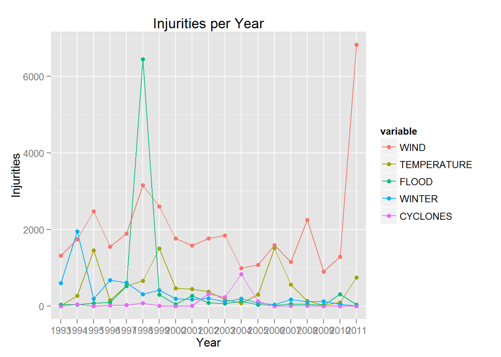

```r
totalInjuritiesByEvent <- with(ReducedStormData, tapply(INJURIES, EVTYPE, FUN=sum))

#sort(totalInjuritiesByEvent, decreasing=TRUE)[1:5]

eventsWithMostInjurities <- names(sort(totalInjuritiesByEvent, decreasing=TRUE)[1:5])

subReducedStormDataInj <- ReducedStormData[ReducedStormData$EVTYPE %in% eventsWithMostInjurities,]

InjuriesByEventsAndYearTab  <- with(subReducedStormDataInj,
                          tapply(INJURIES, list(YEAR, EVTYPE), FUN=sum))

dfIBEAY <- data.frame(InjuriesByEventsAndYearTab)

dfIBEAY$YEAR <- rownames(dfIBEAY)

dfIBEAY <- melt(dfIBEAY, id=c("YEAR"), measure.vars=eventsWithMostInjurities)

pdfIBEAY <- ggplot(dfIBEAY, aes(x=YEAR, y=value, color=variable, group = variable)) +
            geom_point() +
            geom_line() +
            labs(x = "Year", y = "Injurities", title = "Injurities per Year")

print(pdfIBEAY)
```

```r
png("Injuries.png")
```

Respect to fatalities:

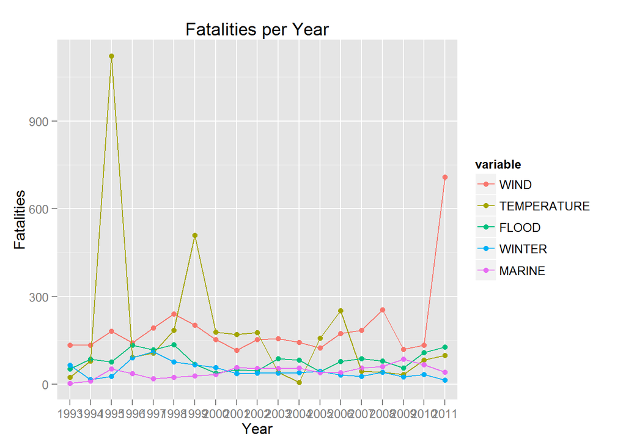

```r
totalFatalitiesByEvent <- with(ReducedStormData, tapply(FATALITIES, EVTYPE, FUN=sum))

eventsWithMostFatalities <- names(sort(totalFatalitiesByEvent, decreasing=TRUE)[1:5])

subReducedStormDataFat <- ReducedStormData[ReducedStormData$EVTYPE %in% eventsWithMostFatalities,]


FatalitiesByEventsAndYearTab  <- with(subReducedStormDataFat,
                            tapply(FATALITIES, list(YEAR, EVTYPE), FUN=sum))

dfFBEAY <- data.frame(FatalitiesByEventsAndYearTab)

dfFBEAY$YEAR <- rownames(dfFBEAY)

dfFBEAY <- melt(dfFBEAY, id=c("YEAR"), measure.vars=eventsWithMostFatalities)

pdfFBEAY <- ggplot(dfFBEAY, aes(x=YEAR, y=value, color=variable, group = variable)) +
            geom_point() +
            geom_line() +
            labs(x = "Year", y = "Fatalities", title = "Fatalities per Year")

print(pdfFBEAY)
```

```r
png("Fatalities.png")
```

Respect to property:

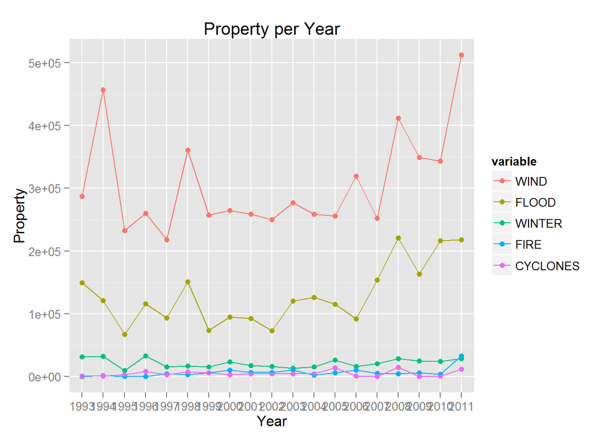

```r
totalPropertyByEvent <- with(ReducedStormData, tapply(PROPDMG, EVTYPE, FUN=sum))

eventsWithMostProperty <- names(sort(totalPropertyByEvent, decreasing=TRUE)[1:5])

subReducedStormDataPro <- ReducedStormData[ReducedStormData$EVTYPE %in% eventsWithMostProperty,]

PropertyByEventsAndYearTab  <- with(subReducedStormDataPro,
                            tapply(PROPDMG, list(YEAR, EVTYPE), FUN=sum))

#FatalitiesByEventsAndYearAgre <- aggregate(FATALITIES  ~ INJURIES, data=ReducedStormData,
#                                            FUN=sum, na.rm=TRUE)

dfPBEAY <- data.frame(PropertyByEventsAndYearTab)

dfPBEAY$YEAR <- rownames(dfPBEAY)

dfPBEAY <- melt(dfPBEAY, id=c("YEAR"), measure.vars=eventsWithMostProperty)

pdfPBEAY <- ggplot(dfPBEAY, aes(x=YEAR, y=value, color=variable, group = variable)) +
            geom_point() +
            geom_line() +
            labs(x = "Year", y = "Property", title = "Property per Year")

print(pdfPBEAY)
```

```r
png("Property.png")
```

## Conclusion

Respect to injurities the most harmful event are wind events, although in some year the most harmful had been th flood events.

Respect to fatalities the most harmful event at 2011 are wind events, although in 1995 the most harmful had been the temperature events.

Finaly, in respect to property, the wind events are the most harmful, followed by flood events.